# Sprawozdanie 3

### Metoda uzupełnienia braków przy pomocy KNN

```r
dane_heart_knn = kNN(dane_heart, k = 5)
```

[output not shown]

```r
summary(dane_heart_knn[,c(1,5,7,9,10)])
```

```
##       Age         Cholesterol     RestingECG  ExerciseAngina    Oldpeak
##  Min.   :28.00   Min.   :  0.0   LVH   :172   N:512          Min.   :-2.6000
##  1st Qu.:47.00   1st Qu.:180.0   Normal:499   Y:306          1st Qu.: 0.0000
##  Median :54.00   Median :220.0   ST    :147                  Median : 0.4000
##  Mean   :53.37   Mean   :199.9                               Mean   : 0.8402
##  3rd Qu.:60.00   3rd Qu.:264.0                               3rd Qu.: 1.5000
##  Max.   :77.00   Max.   :564.0                               Max.   : 6.2000
```

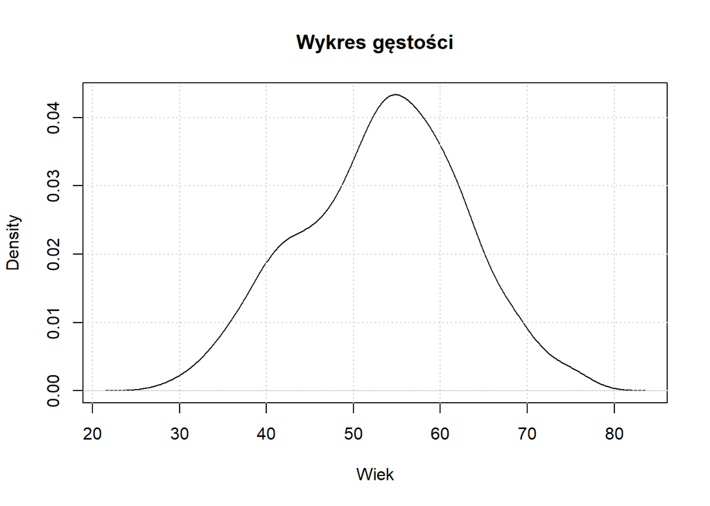

```r
#wykresy gęstości
#wiek
plot(density(dane_heart_knn$Age, na.rm = T),
     main = "Wykres gęstości",
     xlab = "Wiek")
grid()
```

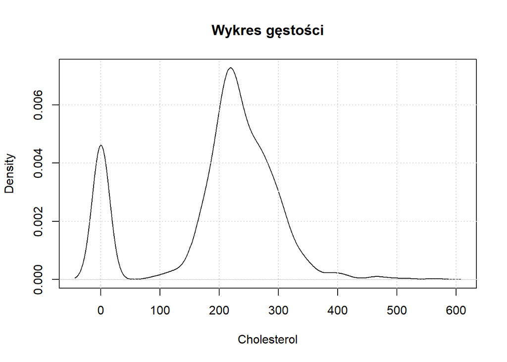

```r
#Cholesterol
plot(density(dane_heart_knn$Cholesterol, na.rm = T),
     main = "Wykres gęstości",
     xlab = "Cholesterol")
grid()
```

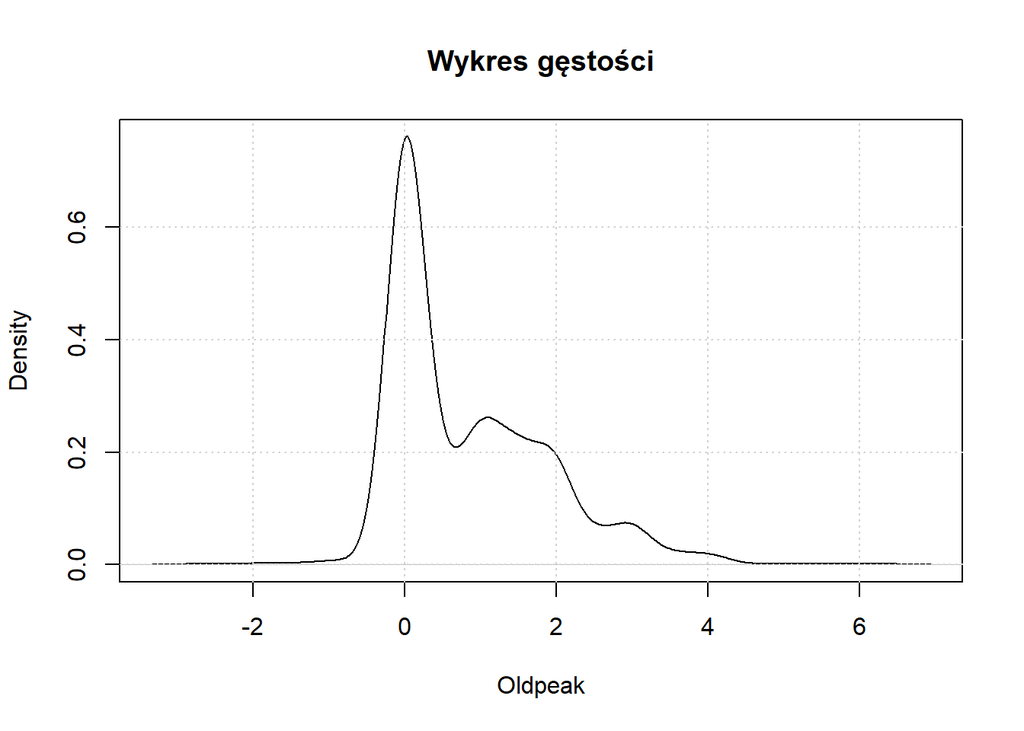

```r
#oldpeak
plot(density(dane_heart_knn$Oldpeak, na.rm = T),
     main = "Wykres gęstości",
     xlab = "Oldpeak")
grid()
```

Wykresy **Cholesterol**

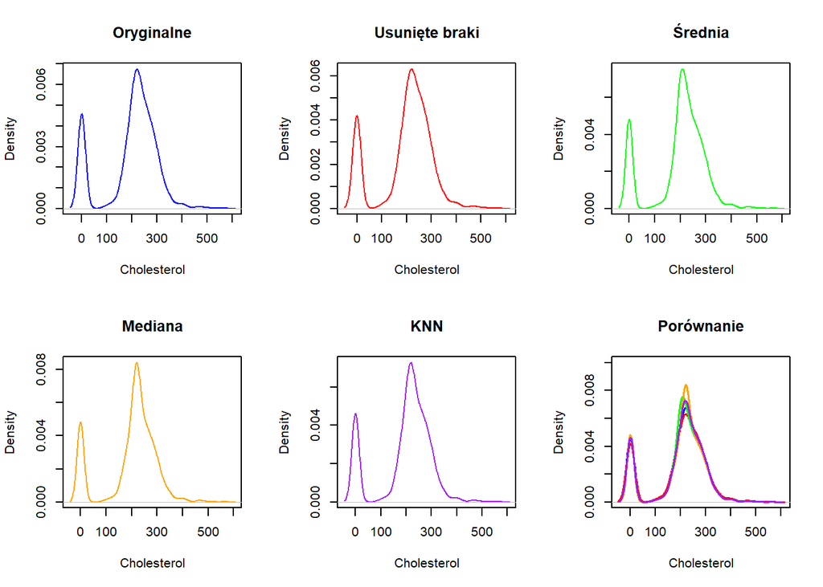

```r
#cholesterol
par(mfrow = c(2, 3))

plot(density(dane_heart$Cholesterol, na.rm = TRUE),
     main = "Oryginalne", xlab = "Cholesterol", col = "blue")

plot(density(dane_heart_omit$Cholesterol, na.rm = TRUE),
     main = "Usunięte braki", xlab = "Cholesterol", col = "red")

plot(density(dane_heart_mean$Cholesterol, na.rm = TRUE),
     main = "Średnia", xlab = "Cholesterol", col = "green")

plot(density(dane_heart_med$Cholesterol, na.rm = TRUE),
     main = "Mediana", xlab = "Cholesterol", col = "orange")

plot(density(dane_heart_knn$Cholesterol, na.rm = TRUE),
     main = "KNN", xlab = "Cholesterol", col = "purple")

plot(density(dane_heart$Cholesterol, na.rm = TRUE),
     main = "Porównanie", xlab = "Cholesterol", col = "blue", lwd = 1.5, ylim= c(0,0.01))
lines(density(dane_heart_omit$Cholesterol, na.rm = TRUE), col = "red", lwd = 1.5)
lines(density(dane_heart_mean$Cholesterol, na.rm = TRUE), col = "green", lwd = 1.5)
lines(density(dane_heart_med$Cholesterol, na.rm = TRUE), col = "orange", lwd = 1.5)
lines(density(dane_heart_knn$Cholesterol, na.rm = TRUE), col = "purple", lwd = 1.5)
```

**Wiek**

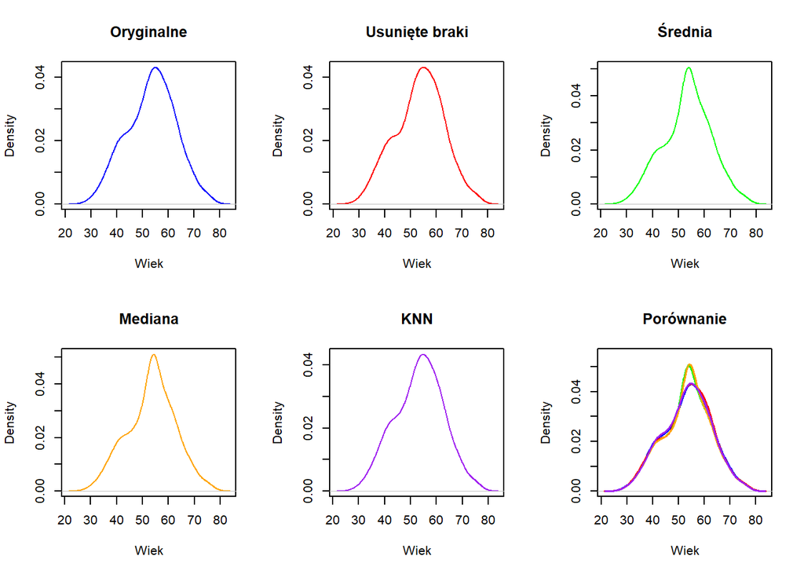

```r
#Wiek
par(mfrow = c(2, 3))

plot(density(dane_heart$Age, na.rm = TRUE),
     main = "Oryginalne", xlab = "Wiek", col = "blue")

plot(density(dane_heart_omit$Age, na.rm = TRUE),
     main = "Usunięte braki", xlab = "Wiek", col = "red")

plot(density(dane_heart_mean$Age, na.rm = TRUE),
     main = "Średnia", xlab = "Wiek", col = "green")

plot(density(dane_heart_med$Age, na.rm = TRUE),
     main = "Mediana", xlab = "Wiek", col = "orange")

plot(density(dane_heart_knn$Age, na.rm = TRUE),
     main = "KNN", xlab = "Wiek", col = "purple")

plot(density(dane_heart$Age, na.rm = TRUE),
     main = "Porównanie", xlab = "Wiek", col = "blue", lwd = 1.5, ylim = c(0, 0.055))
lines(density(dane_heart_omit$Age, na.rm = TRUE), col = "red", lwd = 1.5)
lines(density(dane_heart_mean$Age, na.rm = TRUE), col = "green", lwd = 1.5)
lines(density(dane_heart_med$Age, na.rm = TRUE), col = "orange", lwd = 1.5)
lines(density(dane_heart_knn$Age, na.rm = TRUE), col = "purple", lwd = 1.5)
```

**Oldpeak**

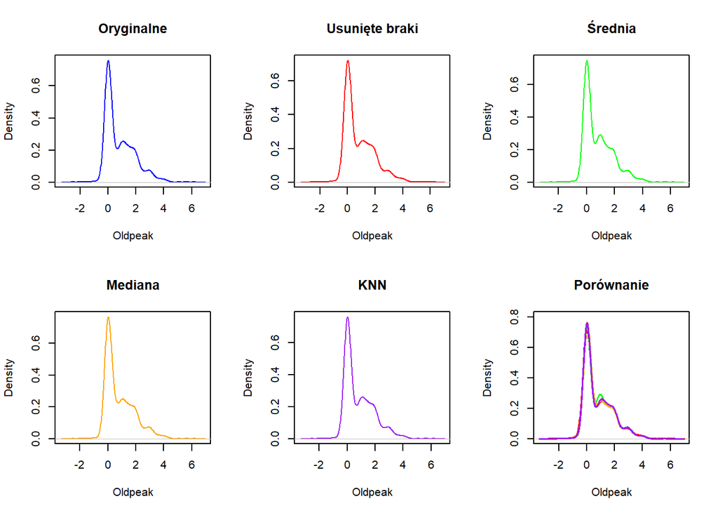

```r
#Oldpeak
par(mfrow = c(2, 3))

plot(density(dane_heart$Oldpeak, na.rm = TRUE),
     main = "Oryginalne", xlab = "Oldpeak", col = "blue")

plot(density(dane_heart_omit$Oldpeak, na.rm = TRUE),
     main = "Usunięte braki", xlab = "Oldpeak", col = "red")

plot(density(dane_heart_mean$Oldpeak, na.rm = TRUE),
     main = "Średnia", xlab = "Oldpeak", col = "green")

plot(density(dane_heart_med$Oldpeak, na.rm = TRUE),
     main = "Mediana", xlab = "Oldpeak", col = "orange")

plot(density(dane_heart_knn$Oldpeak, na.rm = TRUE),
     main = "KNN", xlab = "Oldpeak", col = "purple")

plot(density(dane_heart$Oldpeak, na.rm = TRUE),
     main = "Porównanie", xlab = "Oldpeak", col = "blue", lwd = 1.5, ylim = c(0, 0.8))
lines(density(dane_heart_omit$Oldpeak, na.rm = TRUE), col = "red", lwd = 1.5)
lines(density(dane_heart_mean$Oldpeak, na.rm = TRUE), col = "green", lwd = 1.5)
lines(density(dane_heart_med$Oldpeak, na.rm = TRUE), col = "orange", lwd = 1.5)
lines(density(dane_heart_knn$Oldpeak, na.rm = TRUE), col = "purple", lwd = 1.5)
```

```r
par(mfrow = c(1, 1))
```

## Odpowiedzi na pytania

**Porównanie metod uzupełniania braków danych** Porównanie metod:

- Usuwanie braków – prosta metoda, ale zmniejsza liczność danych
- Średnia – centralizuje dane, przez co zmniejsza wariancję (rozrzut wartości)
- Mediana – stabilna metoda, dobrze zachowuje rozkład, zwłaszcza przy danych skośnych
- KNN – najbardziej zaawansowana i skuteczna metoda, zachowuje strukturę danych i zależności między zmiennymi

**Porównanie statystyk zmiennych przed eliminacją braków danych i po ich eliminacji (po zastosowaniu różnych sposobów)**

**Stroke** W zbiorze danych „Stroke” występowały braki w kilku zmiennych: age, heart_disease, work_type, avg_glucose_level, bmi. Łącznie brakowało 154 wartości.

Porównanie statystyk zmiennych przed i po eliminacji braków danych:

- Po zastosowaniu różnych metod (usunięcie, średnia, mediana, KNN) statystyki takich zmiennych jak wiek, poziom glukozy i BMI pozostały bardzo zbliżone
- Największe różnice dotyczyły BMI – po uzupełnieniu średnią lub medianą rozkład stał się bardziej skupiony wokół wartości centralnych, a odchylenie standardowe nieco się zmniejszyło
- Po imputacji KNN rozkład BMI był najbardziej zbliżony do oryginału
- Ogólnie rozkłady zmiennych nie uległy istotnym zmianom – różnice widoczne są jedynie w spłaszczeniu rozkładu zmiennej z brakami danych.

# Zadanie 2

Sprawdzono czy któryś sposób eliminacji braków danych wpływa na lepsze wyniki modeli uczenia maszynowego. Skorzystano z w tym celu z **Regresji logistycznej**.

## Zestaw Stroke Regresja logistyczna

### Podział na zbiory uczące i testowe

```r
set.seed(123)
index_s_omit = sample(length(dane_stroke_omit$gender), size=0.2*nrow(dane_stroke_omit))
testowy_s_omit = dane_stroke_omit[index_s_omit,]
uczacy_s_omit = dane_stroke_omit[-index_s_omit,]

#standaryzacja
stand = c(2, 8, 9)
uczacy_s_omit[,stand] = scale(uczacy_s_omit[,stand])
testowy_s_omit[,stand] = scale(testowy_s_omit[,stand])

#średnia
index_s_mean = sample(length(dane_stroke_mean$gender), size=0.2*nrow(dane_stroke_mean))
testowy_s_mean = dane_stroke_mean[index_s_mean,]
uczacy_s_mean = dane_stroke_mean[-index_s_mean,]

#stand
uczacy_s_mean[,stand] = scale(uczacy_s_mean[,stand])
testowy_s_mean[,stand] = scale(testowy_s_mean[,stand])

#mediana
index_s_med = sample(length(dane_stroke_med$gender), size=0.2*nrow(dane_stroke_med))
testowy_s_med = dane_stroke_med[index_s_med,]
uczacy_s_med = dane_stroke_med[-index_s_med,]

#stand
uczacy_s_med[,stand] = scale(uczacy_s_med[,stand])
testowy_s_med[,stand] = scale(testowy_s_med[,stand])

#knn
index_s_knn = sample(length(dane_stroke_knn$gender), size=0.2*nrow(dane_stroke_knn))
testowy_s_knn = dane_stroke_knn[index_s_knn,]
uczacy_s_knn = dane_stroke_knn[-index_s_knn,]

#stand
uczacy_s_knn[,stand] = scale(uczacy_s_knn[,stand])
testowy_s_knn[,stand] = scale(testowy_s_knn[,stand])
```

### Usunięte braki danych

```r
glm_model_s_omit = glm(stroke ~ ., data = uczacy_s_omit, family = "binomial")

#Predykcja na zbiorze uczącym
pred_uczacy_s_omit = predict(glm_model_s_omit, newdata = uczacy_s_omit, type = "response")
prog_odciecia = 0.5
klasy_uczacy_s_omit = ifelse(pred_uczacy_s_omit >= prog_odciecia, 1, 0)
confusionMatrix(factor(klasy_uczacy_s_omit), factor(uczacy_s_omit$stroke), positive = "1")
```

```
## Confusion Matrix and Statistics
##
##           Reference
## Prediction  0  1
##          0 90 18
##          1 23 80
##
##                Accuracy : 0.8057
##                  95% CI : (0.7458, 0.8568)
##     No Information Rate : 0.5355
##     P-Value [Acc > NIR] : <2e-16
##
##                   Kappa : 0.6107
##
##  Mcnemar's Test P-Value : 0.5322
##
##             Sensitivity : 0.8163
##             Specificity : 0.7965
##          Pos Pred Value : 0.7767
##          Neg Pred Value : 0.8333
##              Prevalence : 0.4645
##          Detection Rate : 0.3791
##    Detection Prevalence : 0.4882
##       Balanced Accuracy : 0.8064
##
##        'Positive' Class : 1
##
```

```r
#Predykcja na zbiorze testowym
pred_testowy_s_omit = predict(glm_model_s_omit, newdata = testowy_s_omit, type = "response")
klasy_testowy_s_omit = ifelse(pred_testowy_s_omit >= prog_odciecia, 1, 0)
confusionMatrix(factor(klasy_testowy_s_omit), factor(testowy_s_omit$stroke), positive = "1")
```

```
## Confusion Matrix and Statistics
##
##           Reference
## Prediction  0  1
##          0 23  6
##          1  6 17
##
##                Accuracy : 0.7692
##                  95% CI : (0.6316, 0.8747)
##     No Information Rate : 0.5577
##     P-Value [Acc > NIR] : 0.001277
##
##                   Kappa : 0.5322
##
##  Mcnemar's Test P-Value : 1.000000
##
##             Sensitivity : 0.7391
##             Specificity : 0.7931
##          Pos Pred Value : 0.7391
##          Neg Pred Value : 0.7931
##              Prevalence : 0.4423
##          Detection Rate : 0.3269
##    Detection Prevalence : 0.4423
##       Balanced Accuracy : 0.7661
##
##        'Positive' Class : 1
##
```

### Wstawiona średnia i moda

```r
glm_model_s_mean = glm(stroke ~ ., data = uczacy_s_mean, family = "binomial")

#Predykcja na zbiorze uczącym
pred_uczacy_s_mean = predict(glm_model_s_mean, newdata = uczacy_s_mean, type = "response")
klasy_uczacy_s_mean = ifelse(pred_uczacy_s_mean >= prog_odciecia, 1, 0)
confusionMatrix(factor(klasy_uczacy_s_mean), factor(uczacy_s_mean$stroke), positive = "1")
```

```
## Confusion Matrix and Statistics
##
##           Reference
## Prediction   0   1
##          0 123  29
##          1  37 131
##
##                Accuracy : 0.7938
##                  95% CI : (0.7452, 0.8367)
##     No Information Rate : 0.5
##     P-Value [Acc > NIR] : <2e-16
##
##                   Kappa : 0.5875
##
##  Mcnemar's Test P-Value : 0.3889
##
##             Sensitivity : 0.8187
##             Specificity : 0.7688
##          Pos Pred Value : 0.7798
##          Neg Pred Value : 0.8092
##              Prevalence : 0.5000
##          Detection Rate : 0.4094
##    Detection Prevalence : 0.5250
##       Balanced Accuracy : 0.7937
##
##        'Positive' Class : 1
##
```

```r
#Predykcja na zbiorze testowym
pred_testowy_s_mean = predict(glm_model_s_mean, newdata = testowy_s_mean, type = "response")
klasy_testowy_s_mean = ifelse(pred_testowy_s_mean >= prog_odciecia, 1, 0)
confusionMatrix(factor(klasy_testowy_s_mean), factor(testowy_s_mean$stroke), positive = "1")
```

```
## Confusion Matrix and Statistics
##
##           Reference
## Prediction  0  1
##          0 28 10
##          1 12 30
##
##                Accuracy : 0.725
##                  95% CI : (0.6138, 0.819)
##     No Information Rate : 0.5
##     P-Value [Acc > NIR] : 3.505e-05
##
##                   Kappa : 0.45
##
##  Mcnemar's Test P-Value : 0.8312
##
##             Sensitivity : 0.7500
##             Specificity : 0.7000
##          Pos Pred Value : 0.7143
##          Neg Pred Value : 0.7368
##              Prevalence : 0.5000
##          Detection Rate : 0.3750
##    Detection Prevalence : 0.5250
##       Balanced Accuracy : 0.7250
##
##        'Positive' Class : 1
##
```

### Wstawiona mediana i moda

```r
glm_model_s_med = glm(stroke ~ ., data = uczacy_s_med, family = "binomial")

#Predykcja na zbiorze uczącym
pred_uczacy_s_med = predict(glm_model_s_med, newdata = uczacy_s_med, type = "response")
klasy_uczacy_s_med = ifelse(pred_uczacy_s_med >= prog_odciecia, 1, 0)
confusionMatrix(factor(klasy_uczacy_s_med), factor(uczacy_s_med$stroke), positive = "1")
```

```
## Confusion Matrix and Statistics
##
##           Reference
## Prediction   0   1
##          0 125  30
##          1  36 129
##
##                Accuracy : 0.7938
##                  95% CI : (0.7452, 0.8367)
##     No Information Rate : 0.5031
##     P-Value [Acc > NIR] : <2e-16
##
##                   Kappa : 0.5876
##
##  Mcnemar's Test P-Value : 0.5383
##
##             Sensitivity : 0.8113
##             Specificity : 0.7764
##          Pos Pred Value : 0.7818
##          Neg Pred Value : 0.8065
##              Prevalence : 0.4969
##          Detection Rate : 0.4031
##    Detection Prevalence : 0.5156
##       Balanced Accuracy : 0.7939
##
##        'Positive' Class : 1
##
```

```r
#Predykcja na zbiorze testowym
#zamiana Never Worked na Private, z uwagi na problem, gdzie glm() pomija w modelu wartość Never Worked, która nie występuje w zbiorze uczącym
testowy_s_med$work_type <- as.character(testowy_s_med$work_type)
testowy_s_med$work_type[testowy_s_med$work_type == "Never_worked"] <- "Private"
testowy_s_med$work_type <- factor(testowy_s_med$work_type,
                                  levels = levels(uczacy_s_med$work_type))
pred_testowy_s_med = predict(glm_model_s_med, newdata = testowy_s_med, type = "response")
klasy_testowy_s_med = ifelse(pred_testowy_s_med >= prog_odciecia, 1, 0)
confusionMatrix(factor(klasy_testowy_s_med), factor(testowy_s_med$stroke), positive = "1")
```

```
## Confusion Matrix and Statistics
##
##           Reference
## Prediction  0  1
##          0 27  8
##          1 12 33
##
##                Accuracy : 0.75
##                  95% CI : (0.6406, 0.8401)
##     No Information Rate : 0.5125
##     P-Value [Acc > NIR] : 1.164e-05
##
##                   Kappa : 0.4984
##
##  Mcnemar's Test P-Value : 0.5023
##
##             Sensitivity : 0.8049
##             Specificity : 0.6923
##          Pos Pred Value : 0.7333
##          Neg Pred Value : 0.7714
##              Prevalence : 0.5125
##          Detection Rate : 0.4125
##    Detection Prevalence : 0.5625
##       Balanced Accuracy : 0.7486
##
##        'Positive' Class : 1
##
```

### Uzupełnienie braków przy pomocy KNN

```r
glm_model_s_knn = glm(stroke ~ ., data = uczacy_s_knn, family = "binomial")

#Predykcja na zbiorze uczącym
pred_uczacy_s_knn = predict(glm_model_s_knn, newdata = uczacy_s_knn, type = "response")
klasy_uczacy_s_knn = ifelse(pred_uczacy_s_knn >= prog_odciecia, 1, 0)
confusionMatrix(factor(klasy_uczacy_s_knn), factor(uczacy_s_knn$stroke), positive = "1")
```

```
## Confusion Matrix and Statistics
##
##           Reference
## Prediction   0   1
##          0 122  32
##          1  40 126
##
##                Accuracy : 0.775
##                  95% CI : (0.7252, 0.8196)
##     No Information Rate : 0.5062
##     P-Value [Acc > NIR] : <2e-16
##
##                   Kappa : 0.5502
##
##  Mcnemar's Test P-Value : 0.4094
##
##             Sensitivity : 0.7975
##             Specificity : 0.7531
##          Pos Pred Value : 0.7590
##          Neg Pred Value : 0.7922
##              Prevalence : 0.4938
##          Detection Rate : 0.3937
##    Detection Prevalence : 0.5188
##       Balanced Accuracy : 0.7753
##
##        'Positive' Class : 1
##
```

```r
#Predykcja na zbiorze testowym
pred_testowy_s_knn = predict(glm_model_s_knn, newdata = testowy_s_knn, type = "response")
klasy_testowy_s_knn = ifelse(pred_testowy_s_knn >= prog_odciecia, 1, 0)
confusionMatrix(factor(klasy_testowy_s_knn), factor(testowy_s_knn$stroke), positive = "1")
```

```
## Confusion Matrix and Statistics
##
##           Reference
## Prediction  0  1
##          0 31  6
##          1  7 36
##
##                Accuracy : 0.8375
##                  95% CI : (0.7382, 0.9105)
##     No Information Rate : 0.525
##     P-Value [Acc > NIR] : 4.432e-09
##
##                   Kappa : 0.6738
##
##  Mcnemar's Test P-Value : 1
##
##             Sensitivity : 0.8571
##             Specificity : 0.8158
##          Pos Pred Value : 0.8372
##          Neg Pred Value : 0.8378
##              Prevalence : 0.5250
##          Detection Rate : 0.4500
##    Detection Prevalence : 0.5375
##       Balanced Accuracy : 0.8365
##
##        'Positive' Class : 1
##
```

### Porównanie wyników

```r
get_metrics = function(pred, true) {
  cm = confusionMatrix(factor(pred), factor(true), positive = "1")
  data.frame(
    Accuracy    = cm$overall['Accuracy'],
    Sensitivity = cm$byClass['Sensitivity'],
    Specificity = cm$byClass['Specificity'],
    row.names = NULL
  )
}

# Tworzymy tabelę porównawczą
wyniki = bind_rows(
  get_metrics(klasy_testowy_s_omit, testowy_s_omit$stroke) %>% mutate(Model = "Usunięte"),
  get_metrics(klasy_testowy_s_mean, testowy_s_mean$stroke) %>% mutate(Model = "Średnia"),
  get_metrics(klasy_testowy_s_med,  testowy_s_med$stroke)  %>% mutate(Model = "Mediana"),
  get_metrics(klasy_testowy_s_knn,  testowy_s_knn$stroke)  %>% mutate(Model = "KNN")
)

# Porządkowanie kolumn
wyniki = wyniki %>% select(Model, Accuracy, Sensitivity, Specificity)
wyniki
```

```
##      Model  Accuracy Sensitivity Specificity
## 1 Usunięte 0.7692308   0.7391304   0.7931034
## 2  Średnia 0.7250000   0.7500000   0.7000000
## 3  Mediana 0.7500000   0.8048780   0.6923077
## 4      KNN 0.8375000   0.8571429   0.8157895
```

## Zestaw Heart Regresja logistyczna

### Podział na zbiory uczące i testowe

```r
set.seed(123)
# Usunięte
index_h_omit = sample(1:nrow(dane_heart_omit), size = 0.2 * nrow(dane_heart_omit))
testowy_h_omit = dane_heart_omit[index_h_omit, ]
uczacy_h_omit = dane_heart_omit[-index_h_omit, ]

# Średnia
index_h_mean = sample(1:nrow(dane_heart_mean), size = 0.2 * nrow(dane_heart_mean))
testowy_h_mean = dane_heart_mean[index_h_mean, ]
uczacy_h_mean = dane_heart_mean[-index_h_mean, ]

# Mediana
index_h_med = sample(1:nrow(dane_heart_med), size = 0.2 * nrow(dane_heart_med))
testowy_h_med = dane_heart_med[index_h_med, ]
uczacy_h_med = dane_heart_med[-index_h_med, ]

# KNN
index_h_knn = sample(1:nrow(dane_heart_knn), size = 0.2 * nrow(dane_heart_knn))
testowy_h_knn = dane_heart_knn[index_h_knn, ]
uczacy_h_knn = dane_heart_knn[-index_h_knn, ]

#Standaryzacja zmiennych liczbowych
kolumny_num = c("Age", "Cholesterol", "Oldpeak")

uczacy_h_omit[, kolumny_num] = scale(uczacy_h_omit[, kolumny_num])
testowy_h_omit[, kolumny_num] = scale(testowy_h_omit[, kolumny_num])

uczacy_h_mean[, kolumny_num] = scale(uczacy_h_mean[, kolumny_num])
testowy_h_mean[, kolumny_num] = scale(testowy_h_mean[, kolumny_num])

uczacy_h_med[, kolumny_num] = scale(uczacy_h_med[, kolumny_num])
testowy_h_med[, kolumny_num] = scale(testowy_h_med[, kolumny_num])

uczacy_h_knn[, kolumny_num] = scale(uczacy_h_knn[, kolumny_num])
testowy_h_knn[, kolumny_num] = scale(testowy_h_knn[, kolumny_num])
```

### Usunięte braki danych

```r
prog_odciecia = 0.5

# Usunięte
glm_model_h_omit = glm(HeartDisease ~ ., data = uczacy_h_omit, family = "binomial")
pred_testowy_h_omit = predict(glm_model_h_omit, newdata = testowy_h_omit, type = "response")
klasy_testowy_h_omit = ifelse(pred_testowy_h_omit >= prog_odciecia, 1, 0)
confusionMatrix(factor(klasy_testowy_h_omit), factor(testowy_h_omit$HeartDisease), positive = "1")
```

```
## Confusion Matrix and Statistics
##
##           Reference
## Prediction  0  1
##          0 62  5
##          1 12 48
##
##                Accuracy : 0.8661
##                  95% CI : (0.7944, 0.92)
##     No Information Rate : 0.5827
##     P-Value [Acc > NIR] : 3.754e-12
##
##                   Kappa : 0.7298
##
##  Mcnemar's Test P-Value : 0.1456
##
##             Sensitivity : 0.9057
##             Specificity : 0.8378
##          Pos Pred Value : 0.8000
##          Neg Pred Value : 0.9254
##              Prevalence : 0.4173
##          Detection Rate : 0.3780
##    Detection Prevalence : 0.4724
##       Balanced Accuracy : 0.8717
##
##        'Positive' Class : 1
##
```

### Wstawiona średnia i moda

```r
glm_model_h_mean = glm(HeartDisease ~ ., data = uczacy_h_mean, family = "binomial")
pred_testowy_h_mean = predict(glm_model_h_mean, newdata = testowy_h_mean, type = "response")
klasy_testowy_h_mean = ifelse(pred_testowy_h_mean >= prog_odciecia, 1, 0)
confusionMatrix(factor(klasy_testowy_h_mean), factor(testowy_h_mean$HeartDisease), positive = "1")
```

```
## Confusion Matrix and Statistics
##
##           Reference
## Prediction  0  1
##          0 67 14
##          1  7 75
##
##                Accuracy : 0.8712
##                  95% CI : (0.8098, 0.9184)
##     No Information Rate : 0.546
##     P-Value [Acc > NIR] : <2e-16
##
##                   Kappa : 0.7422
##
##  Mcnemar's Test P-Value : 0.1904
##
##             Sensitivity : 0.8427
##             Specificity : 0.9054
##          Pos Pred Value : 0.9146
##          Neg Pred Value : 0.8272
##              Prevalence : 0.5460
##          Detection Rate : 0.4601
##    Detection Prevalence : 0.5031
##       Balanced Accuracy : 0.8741
##
##        'Positive' Class : 1
##
```

### Wstawiona mediana i moda

```r
glm_model_h_med = glm(HeartDisease ~ ., data = uczacy_h_med, family = "binomial")
pred_testowy_h_med = predict(glm_model_h_med, newdata = testowy_h_med, type = "response")
klasy_testowy_h_med = ifelse(pred_testowy_h_med >= prog_odciecia, 1, 0)
confusionMatrix(factor(klasy_testowy_h_med), factor(testowy_h_med$HeartDisease), positive = "1")
```

```
## Confusion Matrix and Statistics
##
##           Reference
## Prediction  0  1
##          0 70 10
##          1 15 68
##
##                Accuracy : 0.8466
##                  95% CI : (0.782, 0.8982)
##     No Information Rate : 0.5215
##     P-Value [Acc > NIR] : <2e-16
##
##                   Kappa : 0.6935
##
##  Mcnemar's Test P-Value : 0.4237
##
##             Sensitivity : 0.8718
##             Specificity : 0.8235
##          Pos Pred Value : 0.8193
##          Neg Pred Value : 0.8750
##              Prevalence : 0.4785
##          Detection Rate : 0.4172
##    Detection Prevalence : 0.5092
##       Balanced Accuracy : 0.8477
##
##        'Positive' Class : 1
##
```

### Uzupełnienie braków przy pomocy KNN

```r
glm_model_h_knn = glm(HeartDisease ~ ., data = uczacy_h_knn, family = "binomial")
pred_testowy_h_knn = predict(glm_model_h_knn, newdata = testowy_h_knn, type = "response")
klasy_testowy_h_knn = ifelse(pred_testowy_h_knn >= prog_odciecia, 1, 0)
confusionMatrix(factor(klasy_testowy_h_knn), factor(testowy_h_knn$HeartDisease), positive = "1")
```

```
## Confusion Matrix and Statistics
##
##           Reference
## Prediction  0  1
##          0 72  9
##          1 12 70
##
##                Accuracy : 0.8712
##                  95% CI : (0.8098, 0.9184)
##     No Information Rate : 0.5153
##     P-Value [Acc > NIR] : <2e-16
##
##                   Kappa : 0.7424
##
##  Mcnemar's Test P-Value : 0.6625
##
##             Sensitivity : 0.8861
##             Specificity : 0.8571
##          Pos Pred Value : 0.8537
##          Neg Pred Value : 0.8889
##              Prevalence : 0.4847
##          Detection Rate : 0.4294
##    Detection Prevalence : 0.5031
##       Balanced Accuracy : 0.8716
##
##        'Positive' Class : 1
##
```

### Porównanie wyników

```r
get_metrics = function(pred, true) {
  cm = confusionMatrix(factor(pred), factor(true), positive = "1")
  data.frame(
    Accuracy    = cm$overall['Accuracy'],
    Sensitivity = cm$byClass['Sensitivity'],
    Specificity = cm$byClass['Specificity'],
    row.names = NULL
  )
}

wyniki_heart = bind_rows(
  get_metrics(klasy_testowy_h_omit, testowy_h_omit$HeartDisease) %>% mutate(Model = "Usunięte"),
  get_metrics(klasy_testowy_h_mean, testowy_h_mean$HeartDisease) %>% mutate(Model = "Średnia"),
  get_metrics(klasy_testowy_h_med,  testowy_h_med$HeartDisease)  %>% mutate(Model = "Mediana"),
  get_metrics(klasy_testowy_h_knn,  testowy_h_knn$HeartDisease)  %>% mutate(Model = "KNN")
)

wyniki_heart = wyniki_heart %>% select(Model, Accuracy, Sensitivity, Specificity)
wyniki_heart
```

```
##      Model  Accuracy Sensitivity Specificity
## 1 Usunięte 0.8661417   0.9056604   0.8378378
## 2  Średnia 0.8711656   0.8426966   0.9054054
## 3  Mediana 0.8466258   0.8717949   0.8235294
## 4      KNN 0.8711656   0.8860759   0.8571429
```

## Odpowiedzi na pytania

**Stroke** Dla zestawu danych `Stroke` otrzymano niejednoznaczne wyniki dla modeli na 4 zbiorach z wyeliminowanymi brakami danych. Najwyższą czułością charakteryzował się model na zbiorze, gdzie braki danych zostały uzupełnione za pomocą KNN (w kontekście danych mógłby to być najlepszy model, z uwagi na to, że model ma szukać skutecznie przypadków osób, które mają chorobę). Na podstawie uzyskanych wyników najgorszym modelem był model zbudowany na zbiorze, gdzie braki danych zostały uzupełnione średnią, a najlepszy na zbiorze uzupełnionym metodą KNN.

**Heart** Dla zestawu danych `Heart` otrzymano podobne wyniki dla modeli na 4 zbiorach z wyeliminowanymi brakami danych. Najwyższą czułością charakteryzował się model na zbiorze, gdzie braki danych zostały usunięte (w kontekście danych mógłby to być najlepszy model, z uwagi na to, że model ma szukać skutecznie przypadków osób, które mają chorobę). Jednak ciężko jednoznacznie wskazać, który sposób eliminacji danych najlepiej wpływa na jakość modelu.